# Why is the weighted IEG score a ‘worse classifier’ in SE than in EE30m?

Author

jack

# The question

In `Figure4_SuppFig2.R` we treat the binary active-cell call from `FindActiveCells()` (90th-percentile threshold, >= 3 IEGs) as ground truth and ask how well the continuous `WeightedActivityScore()` recovers it. The PR curves give:

| condition | AUPRC (scale = SE) | AUPRC (scale = EE30m) |
| --- | --- | --- |
| SE | 0.850 | 0.873 |
| EE30m | 0.974 | 0.979 |
| KA30m | 1.000 | 1.000 |

Read naively this says “the score is a poor classifier in SE.” This notebook argues that reading is wrong, and works through four candidate explanations:

- **H1 — Prevalence.** PR curves are not comparable across conditions with different positive rates. A random classifier scores AUPRC ≈ prevalence, and prevalence is low in SE by construction and ≈ 1 in KA30m. The KA30m “AUPRC = 1” is the tell.
- **H2 — Boundary crowding.** In SE, positives sit *at* the decision boundary (exactly 3 IEGs, each barely over threshold), so any continuous score has to resolve a distinction the binary rule itself makes arbitrarily.
- **H3 — Count vs. mean.** The two summaries measure different things: the binary rule counts genes over a per-gene threshold; the score averages z-scores. These disagree in specific, identifiable ways (one dominant gene vs. many weak genes).
- **H4 — Scale condition.** Whether we z-score against SE or EE30m only reweights genes. It should matter little, and the table above suggests it doesn’t.

The punchline, tested below: **H1 accounts for most of the gap, H2/H3 for the remainder, and H4 for almost none.** “AUPRC = 1” in KA30m is not a better classifier — it is a degenerate one.

```r
knitr::opts_chunk$set(message = FALSE)
#| message: false
#| warning: false

source("03-scripts/R/seq_functions.R")
```

[output not shown]

[output not shown]

```
Helvetica is now the default font for ggplot2.
```

```r
library(pROC)
library(PRROC)
library(gt)
library(patchwork)
library(purrr)
theme_set(theme_bw())

conditions      <- c("SE", "EE30m", "KA30m")
IEG_symbols     <- LoadGeneList("IEG")
activity_colors <- LoadActivityColors()

set.seed(42)
```

```r
if (!exists("nuclei_ca1")) {
  nuclei_ca1 <- readRDS("04-analysis/Seurats/nuclei_ca1.rds")
}

# binary reference call (identical to Figure 4D-E and Figure4_SuppFig2.R)
if (!exists("FindActiveCells_CA1_outputs")) {
  FindActiveCells_CA1_outputs <- FindActiveCells(
    nuclei_ca1,
    subclass       = "016 CA1-ProS Glut",
    gene_list      = IEG_symbols,
    gene_threshold = 3L
  )
}
# continuous score, z-scored against each of the two candidate scale conditions
if (!exists("WAS_scaleSE")) {
  WAS_scaleSE <- WeightedActivityScore(
    nuclei_ca1,
    subclass        = "016 CA1-ProS Glut",
    gene_list       = IEG_symbols,
    scale_condition = "SE"
  )
}
if (!exists("WAS_scaleEE")) {
  WAS_scaleEE <- WeightedActivityScore(
    nuclei_ca1,
    subclass        = "016 CA1-ProS Glut",
    gene_list       = IEG_symbols,
    scale_condition = "EE30m"
  )
}
df_active   <- FindActiveCells_CA1_outputs$df_active_cells
thresholds  <- FindActiveCells_CA1_outputs$activation_thresholds
gene_cols   <- names(thresholds)

df <- df_active |>
  filter(activity_condition %in% conditions) |>
  mutate(activity_condition = factor(activity_condition, levels = conditions)) |>
  left_join(
    WAS_scaleSE$df_weighted_score |>
      dplyr::select(cell, score_scaleSE = weighted_ieg_score),
    by = "cell"
  ) |>
  left_join(
    WAS_scaleEE$df_weighted_score |>
      dplyr::select(cell, score_scaleEE = weighted_ieg_score),
    by = "cell"
  ) |>
  mutate(active_ref = active_binary)

glue::glue("{nrow(df)} CA1 cells across {length(conditions)} conditions; {length(gene_cols)} IEGs")
```

```
14833 CA1 cells across 3 conditions; 15 IEGs
```

# H1 — Prevalence: the PR curve’s baseline moves with the condition

```r
prevalence <- df |>
  group_by(activity_condition) |>
  summarise(
    n_cells    = n(),
    n_active   = sum(active_ref),
    n_inactive = sum(!active_ref),
    prevalence = mean(active_ref),
    .groups = "drop"
  )

prevalence |>
  gt() |>
  tab_header(title = "Positive-class prevalence by condition",
             subtitle = "Binary reference: 90th pct (SE-derived), >= 3 IEGs") |>
  fmt_number(columns = c(n_cells, n_active, n_inactive), decimals = 0, use_seps = TRUE) |>
  fmt_percent(columns = prevalence, decimals = 1)
```

Positive-class prevalence by condition

Binary reference: 90th pct (SE-derived), >= 3 IEGs

| activity_condition | n_cells | n_active | n_inactive | prevalence |
| --- | --- | --- | --- | --- |
| SE | 6,753 | 419 | 6,334 | 6.2% |
| EE30m | 7,119 | 2,374 | 4,745 | 33.3% |
| KA30m | 961 | 957 | 4 | 99.6% |

## Prevalence-aware metrics

Three things worth putting side by side:

- **AUPRC** — what the figure shows; prevalence-dependent.
- **Normalised AUPRC** = (AUPRC − prevalence) / (1 − prevalence) — how far the classifier gets from the random baseline toward perfection. Comparable across prevalences.
- **ROC-AUC** — prevalence-invariant by construction. If the SE “problem” is prevalence, ROC-AUC should be flat across conditions while AUPRC is not.

```r
pr_auc <- function(scores, labels) {
  if (sum(labels) < 2 || sum(!labels) < 2) return(NA_real_)
  PRROC::pr.curve(scores.class0 = scores[labels],
                  scores.class1 = scores[!labels])$auc.integral
}

roc_auc <- function(scores, labels) {
  if (sum(labels) < 2 || sum(!labels) < 2) return(NA_real_)
  as.numeric(pROC::auc(pROC::roc(labels, scores, quiet = TRUE)))
}

metrics <- df |>
  group_by(activity_condition) |>
  summarise(
    prevalence = mean(active_ref),
    auprc      = pr_auc(score_scaleEE, active_ref),
    roc        = roc_auc(score_scaleEE, active_ref),
    .groups = "drop"
  ) |>
  mutate(auprc_normalised = (auprc - prevalence) / (1 - prevalence))

metrics |>
  gt() |>
  tab_header(title = "AUPRC is prevalence-bound; ROC-AUC and normalised AUPRC are not",
             subtitle = "Score z-scored against EE30m") |>
  cols_label(prevalence = "Prevalence (= random-classifier AUPRC)",
             auprc = "AUPRC", roc = "ROC-AUC",
             auprc_normalised = "Normalised AUPRC") |>
  fmt_number(columns = c(auprc, roc, auprc_normalised), decimals = 3) |>
  fmt_percent(columns = prevalence, decimals = 1)
```

AUPRC is prevalence-bound; ROC-AUC and normalised AUPRC are not

Score z-scored against EE30m

| activity_condition | Prevalence (= random-classifier AUPRC) | AUPRC | ROC-AUC | Normalised AUPRC |
| --- | --- | --- | --- | --- |
| SE | 6.2% | 0.873 | 0.988 | 0.865 |
| EE30m | 33.3% | 0.979 | 0.989 | 0.968 |
| KA30m | 99.6% | 1.000 | 1.000 | 1.000 |

**Read the KA30m row first.** If prevalence is near 1, essentially every cell is a positive, precision is ~1 no matter how the score ranks cells, and AUPRC = 1 is unavoidable. Normalised AUPRC divides by (1 − prevalence), which is near zero there, so that column is numerically unstable for KA30m — treat it as undefined rather than meaningful, and lean on ROC-AUC for that condition.

## PR curves with their baselines drawn in

The same curves as the figure, but with each condition’s random-classifier floor as a dashed line. The visual gap to *its own* baseline is the honest comparison.

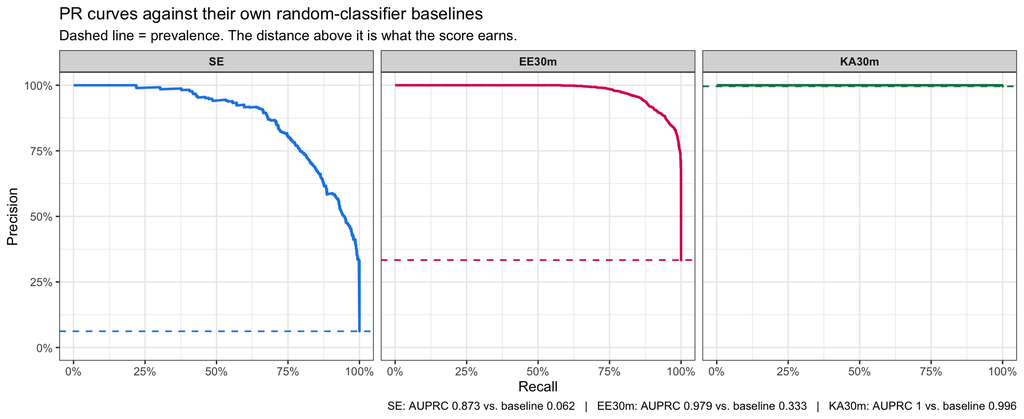

```r
pr_curve_df <- function(d, cond, score_col) {
  s <- d[[score_col]]
  pr <- PRROC::pr.curve(scores.class0 = s[d$active_ref],
                        scores.class1 = s[!d$active_ref],
                        curve = TRUE)
  as_tibble(pr$curve) |>
    setNames(c("recall", "precision", "threshold")) |>
    mutate(condition = cond, auprc = pr$auc.integral)
}

pr_all <- purrr::map_dfr(conditions, \(cond) {
  pr_curve_df(filter(df, activity_condition == cond), cond, "score_scaleEE")
}) |>
  mutate(condition = factor(condition, levels = conditions)) |>
  left_join(prevalence |> dplyr::select(condition = activity_condition, prevalence),
            by = "condition")
pr_labels <- pr_all |>
  distinct(condition, auprc, prevalence) |>
  mutate(lab = glue::glue("{condition}: AUPRC {round(auprc, 3)} vs. baseline {round(prevalence, 3)}"))

ggplot(pr_all) +
  aes(x = recall, y = precision, color = condition) +
  geom_hline(aes(yintercept = prevalence, color = condition),
             linetype = "dashed", linewidth = 0.6) +
  geom_line(linewidth = 0.9) +
  scale_color_manual(values = activity_colors[conditions], guide = "none") +
  scale_x_continuous(labels = scales::percent) +
  scale_y_continuous(labels = scales::percent, limits = c(0, 1)) +
  facet_wrap(~condition, nrow = 1) +
  labs(
    x = "Recall", y = "Precision",
    title = "PR curves against their own random-classifier baselines",
    subtitle = "Dashed line = prevalence. The distance above it is what the score earns.",
    caption = paste(pr_labels$lab, collapse = "   |   ")
  ) +
  theme(strip.text = element_text(face = "bold"))
```

## The decisive test: match the prevalence

If prevalence is the explanation, then artificially lowering EE30m and KA30m to SE’s positive rate — by subsampling positives, leaving the score untouched — should drag their AUPRCs down toward SE’s. Nothing about the classifier changes; only the class balance does.

```r
target_prev <- min(prevalence$prevalence)
n_reps      <- 50

subsample_to_prevalence <- function(d, target, score_col) {
  pos <- which(d$active_ref)
  neg <- which(!d$active_ref)
  # keep all negatives, thin the positives down to the target rate
  n_pos_keep <- floor(length(neg) * target / (1 - target))
  if (n_pos_keep < 2 || n_pos_keep > length(pos)) return(NA_real_)
  keep <- c(sample(pos, n_pos_keep), neg)
  pr_auc(d[[score_col]][keep], d$active_ref[keep])
}

matched <- map_dfr(conditions, \(cond) {
  d <- filter(df, activity_condition == cond)
  tibble(
    condition   = cond,
    rep         = seq_len(n_reps),
    auprc_matched = map_dbl(seq_len(n_reps),
                            \(i) subsample_to_prevalence(d, target_prev, "score_scaleEE"))
  )
}) |>
  mutate(condition = factor(condition, levels = conditions))

matched_summary <- matched |>
  group_by(condition) |>
  summarise(
    auprc_matched_mean = mean(auprc_matched, na.rm = TRUE),
    auprc_matched_sd   = sd(auprc_matched, na.rm = TRUE),
    .groups = "drop"
  ) |>
  left_join(metrics |> dplyr::select(condition = activity_condition, auprc_observed = auprc),
            by = "condition")

matched_summary |>
  gt() |>
  tab_header(
    title = glue::glue("AUPRC after subsampling every condition to {round(target_prev * 100, 1)}% prevalence"),
    subtitle = glue::glue("{n_reps} subsamples; the score itself is unchanged")
  ) |>
  fmt_number(columns = where(is.numeric), decimals = 3)
```

AUPRC after subsampling every condition to 6.2% prevalence

50 subsamples; the score itself is unchanged

| condition | auprc_matched_mean | auprc_matched_sd | auprc_observed |
| --- | --- | --- | --- |
| SE | 0.873 | 0.000 | 0.873 |
| EE30m | 0.905 | 0.010 | 0.979 |
| KA30m | NaN | NA | 1.000 |

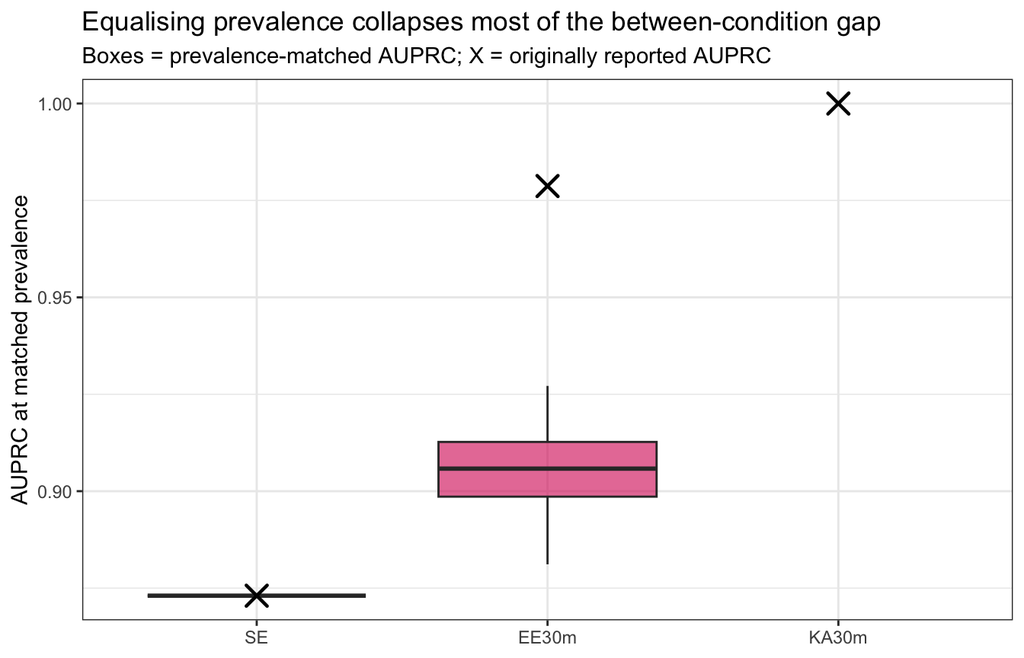

```r
ggplot(matched) +
  aes(x = condition, y = auprc_matched, fill = condition) +
  geom_boxplot(alpha = 0.6, outlier.size = 0.7) +
  geom_point(data = matched_summary,
             aes(x = condition, y = auprc_observed),
             shape = 4, size = 4, stroke = 1.2, inherit.aes = FALSE) +
  scale_fill_manual(values = activity_colors[conditions], guide = "none") +
  labs(
    x = NULL, y = "AUPRC at matched prevalence",
    title = "Equalising prevalence collapses most of the between-condition gap",
    subtitle = "Boxes = prevalence-matched AUPRC; X = originally reported AUPRC"
  )
```

If the boxes land far closer together than the X marks, H1 is carrying the explanation. Whatever separation *survives* matching is real, and H2/H3 are about that residue.

# H2 — In SE, the positives sit on the decision boundary

The binary rule is a step function on a count. A cell with 3 IEGs a hair over threshold is a positive; a cell with 2 IEGs far over is a negative. In EE30m/KA30m, active cells clear the bar with room to spare, so almost any sensible continuous score orders them correctly. In SE, the positives are *by construction* the marginal cells — they are the right tail of the very distribution that defined the threshold.

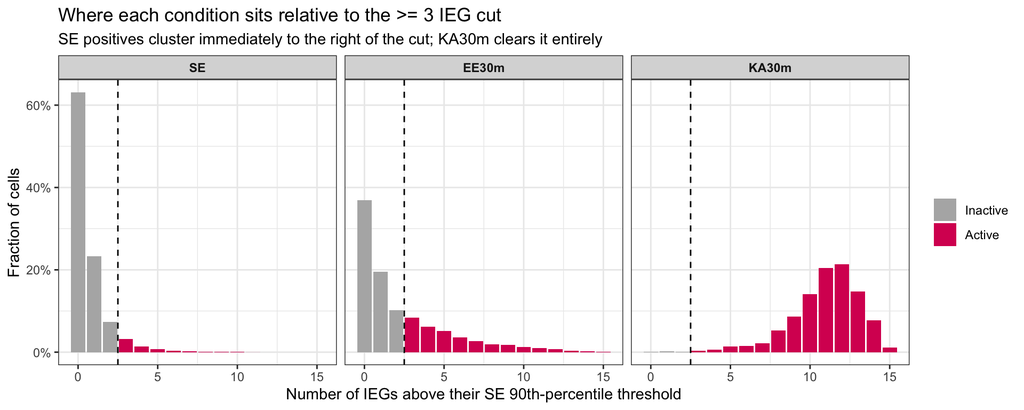

```r
df |>
  count(activity_condition, num_upregd_genes) |>
  group_by(activity_condition) |>
  mutate(frac = n / sum(n)) |>
  ungroup() |>
  ggplot() +
  aes(x = num_upregd_genes, y = frac, fill = num_upregd_genes >= 3) +
  geom_col() +
  geom_vline(xintercept = 2.5, linetype = "dashed") +
  scale_fill_manual(values = c("FALSE" = "gray70", "TRUE" = "#D81B60"),
                    labels = c("FALSE" = "Inactive", "TRUE" = "Active"),
                    name = NULL) +
  scale_y_continuous(labels = scales::percent) +
  facet_wrap(~activity_condition, nrow = 1) +
  labs(
    x = "Number of IEGs above their SE 90th-percentile threshold",
    y = "Fraction of cells",
    title = "Where each condition sits relative to the >= 3 IEG cut",
    subtitle = "SE positives cluster immediately to the right of the cut; KA30m clears it entirely"
  ) +
  theme(strip.text = element_text(face = "bold"))
```

```r
df |>
  group_by(activity_condition) |>
  summarise(
    n_active          = sum(active_ref),
    frac_active_at_3  = sum(active_ref & num_upregd_genes == 3) / pmax(sum(active_ref), 1),
    frac_inactive_at_2 = sum(!active_ref & num_upregd_genes == 2) / pmax(sum(!active_ref), 1),
    median_n_active   = median(num_upregd_genes[active_ref]),
    .groups = "drop"
  ) |>
  gt() |>
  tab_header(title = "How marginal are the positives?",
             subtitle = "Cells with exactly 3 IEGs over threshold are one gene away from being negative") |>
  cols_label(frac_active_at_3 = "Active cells with exactly 3",
             frac_inactive_at_2 = "Inactive cells with exactly 2",
             median_n_active = "Median IEG count among actives") |>
  fmt_percent(columns = starts_with("frac"), decimals = 1) |>
  fmt_number(columns = c(n_active, median_n_active), decimals = 0)
```

How marginal are the positives?

Cells with exactly 3 IEGs over threshold are one gene away from being negative

| activity_condition | n_active | Active cells with exactly 3 | Inactive cells with exactly 2 | Median IEG count among actives |
| --- | --- | --- | --- | --- |
| SE | 419 | 50.8% | 7.8% | 3 |
| EE30m | 2,374 | 25.1% | 15.2% | 5 |
| KA30m | 957 | 0.3% | 25.0% | 11 |

The score-vs-count relationship makes the same point continuously. The classifier’s job is to place a cutoff on the x-axis that reproduces the y-axis split at 2/3 genes.

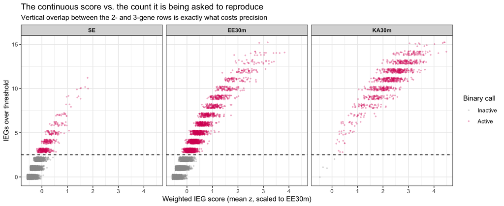

```r
ggplot(df) +
  aes(x = score_scaleEE, y = num_upregd_genes, color = active_ref) +
  geom_hline(yintercept = 2.5, linetype = "dashed") +
  geom_jitter(height = 0.25, width = 0, alpha = 0.25, size = 0.6) +
  scale_color_manual(values = c("FALSE" = "gray60", "TRUE" = "#D81B60"),
                     labels = c("FALSE" = "Inactive", "TRUE" = "Active"),
                     name = "Binary call") +
  facet_wrap(~activity_condition, nrow = 1) +
  labs(
    x = "Weighted IEG score (mean z, scaled to EE30m)",
    y = "IEGs over threshold",
    title = "The continuous score vs. the count it is being asked to reproduce",
    subtitle = "Vertical overlap between the 2- and 3-gene rows is exactly what costs precision"
  ) +
  theme(strip.text = element_text(face = "bold"))
```

```r
df |>
  group_by(activity_condition) |>
  summarise(
    spearman_score_vs_count = cor(score_scaleEE, num_upregd_genes, method = "spearman"),
    .groups = "drop"
  ) |>
  gt() |>
  tab_header(title = "Rank agreement between the score and the underlying IEG count") |>
  fmt_number(columns = spearman_score_vs_count, decimals = 3)
```

Rank agreement between the score and the underlying IEG count

| activity_condition | spearman_score_vs_count |
| --- | --- |
| SE | 0.741 |
| EE30m | 0.924 |
| KA30m | 0.853 |

# H3 — The two summaries genuinely measure different things

Neither quantity is truth. The binary rule asks *how many* IEGs are elevated; the score asks *how elevated* the panel is on average. Two cell types break the correspondence:

- **False positives:** one or two IEGs enormously high (e.g. only `Fos`), pulling the mean up while the count stays below 3.
- **False negatives:** many IEGs mildly elevated — three of them just over threshold — but no single gene high enough to lift the mean.

We can label these directly. Pick the score cutoff that maximises F1 within each condition (the most generous possible reading of the score-as-classifier), then inspect who is misassigned.

```r
best_f1_cut <- function(scores, labels) {
  cand <- quantile(scores, probs = seq(0.01, 0.99, by = 0.01), names = FALSE)
  f1 <- map_dbl(cand, \(k) {
    pred <- scores >= k
    tp <- sum(pred & labels); fp <- sum(pred & !labels); fn <- sum(!pred & labels)
    if (tp == 0) return(0)
    2 * tp / (2 * tp + fp + fn)
  })
  cand[which.max(f1)]
}

df_disc <- df |>
  group_by(activity_condition) |>
  mutate(
    cutoff = best_f1_cut(score_scaleEE, active_ref),
    pred   = score_scaleEE >= cutoff,
    call   = case_when(
       pred &  active_ref ~ "True positive",
      !pred & !active_ref ~ "True negative",
       pred & !active_ref ~ "False positive",
      !pred &  active_ref ~ "False negative"
    )
  ) |>
  ungroup()

df_disc |>
  count(activity_condition, call) |>
  group_by(activity_condition) |>
  mutate(frac = n / sum(n)) |>
  ungroup() |>
  pivot_wider(id_cols = activity_condition, names_from = call, values_from = frac,
              values_fill = 0) |>
  gt() |>
  tab_header(title = "Confusion at each condition's best-F1 cutoff",
             subtitle = "Fraction of that condition's cells") |>
  fmt_percent(columns = -activity_condition, decimals = 1)
```

Confusion at each condition's best-F1 cutoff

Fraction of that condition's cells

| activity_condition | False negative | False positive | True negative | True positive |
| --- | --- | --- | --- | --- |
| SE | 1.5% | 1.3% | 92.5% | 4.7% |
| EE30m | 2.2% | 3.9% | 62.8% | 31.1% |
| KA30m | 0.6% | 0.0% | 0.4% | 99.0% |

Now the gene-level anatomy of the errors. For each cell, compare the *concentration* of IEG signal (how much the single top gene dominates) against the *breadth* (how many genes are over threshold).

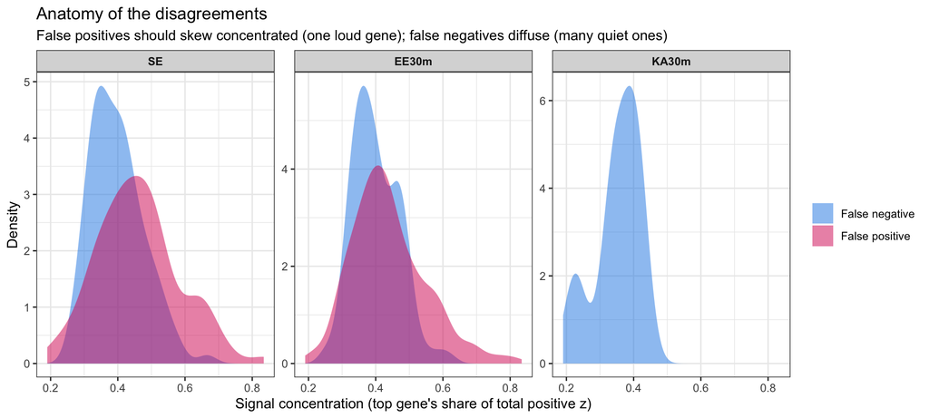

```r
# WeightedActivityScore() already returns the per-gene z-scores it averaged;
# pull those rather than recomputing, so this matches the score exactly.
z_cols <- paste0(gene_cols, "_z")

z_mat <- WAS_scaleEE$df_weighted_score |>
  dplyr::select(cell, all_of(z_cols)) |>
  # align to df's row order
  right_join(dplyr::select(df_disc, cell), by = "cell") |>
  dplyr::select(all_of(z_cols)) |>
  as.matrix()

stopifnot(nrow(z_mat) == nrow(df_disc))

df_anatomy <- df_disc |>
  mutate(
    top_gene       = gene_cols[max.col(z_mat, ties.method = "first")],
    max_z          = apply(z_mat, 1, max),
    mean_z         = rowMeans(z_mat),
    # how much of the total signal the single strongest gene accounts for
    concentration  = max_z / pmax(rowSums(pmax(z_mat, 0)), .Machine$double.eps)
  )

ggplot(filter(df_anatomy, call %in% c("False positive", "False negative"))) +
  aes(x = concentration, fill = call) +
  geom_density(alpha = 0.5, color = NA) +
  scale_fill_manual(values = c("False positive" = "#D81B60", "False negative" = "#1E88E5"),
                    name = NULL) +
  facet_wrap(~activity_condition, nrow = 1, scales = "free_y") +
  labs(
    x = "Signal concentration (top gene's share of total positive z)",
    y = "Density",
    title = "Anatomy of the disagreements",
    subtitle = "False positives should skew concentrated (one loud gene); false negatives diffuse (many quiet ones)"
  ) +
  theme(strip.text = element_text(face = "bold"))
```

```r
df_anatomy |>
  filter(call == "False positive") |>
  count(activity_condition, top_gene) |>
  group_by(activity_condition) |>
  slice_max(n, n = 5) |>
  ungroup() |>
  gt(groupname_col = "activity_condition") |>
  tab_header(title = "Which IEG most often drives a false positive",
             subtitle = "Cells the score calls active but the >= 3-gene rule does not")
```

Which IEG most often drives a false positive

Cells the score calls active but the >= 3-gene rule does not

| top_gene | n |
| --- | --- |
| SE |  |
| Egr4 | 21 |
| Dusp1 | 17 |
| Fos | 8 |
| Fosl2 | 6 |
| Junb | 6 |
| Nr4a1 | 6 |
| EE30m |  |
| Dusp1 | 35 |
| Egr4 | 31 |
| Junb | 30 |
| Dusp5 | 28 |
| Arc | 26 |

A related check: are the thresholds themselves degenerate for sparse IEGs? If a gene’s SE 90th percentile is 0, then “over threshold” collapses to “detected at all,” which makes the binary rule noisier in exactly the condition where counts are lowest.

```r
tibble(gene = names(thresholds), threshold_90th_SE = as.numeric(thresholds)) |>
  left_join(
    df |>
      filter(activity_condition == "SE") |>
      dplyr::select(all_of(gene_cols)) |>
      pivot_longer(everything(), names_to = "gene", values_to = "expr") |>
      group_by(gene) |>
      summarise(frac_zero_in_SE = mean(expr == 0), .groups = "drop"),
    by = "gene"
  ) |>
  arrange(desc(frac_zero_in_SE)) |>
  gt() |>
  tab_header(title = "Per-gene SE thresholds and sparsity",
             subtitle = "A threshold of 0 means the binary rule reduces to detection") |>
  fmt_number(columns = threshold_90th_SE, decimals = 3) |>
  fmt_percent(columns = frac_zero_in_SE, decimals = 1)
```

Per-gene SE thresholds and sparsity

A threshold of 0 means the binary rule reduces to detection

| gene | threshold_90th_SE | frac_zero_in_SE |
| --- | --- | --- |
| Egr2 | 0.000 | 98.9% |
| Fosb | 0.000 | 98.6% |
| Btg2 | 0.000 | 98.4% |
| Egr4 | 0.000 | 98.2% |
| Fos | 0.000 | 97.6% |
| Dusp1 | 0.000 | 94.8% |
| Junb | 0.000 | 91.9% |
| Npas4 | 0.693 | 88.0% |
| Dusp5 | 0.693 | 82.4% |
| Egr1 | 0.693 | 80.4% |
| Arc | 0.693 | 78.9% |
| Fosl2 | 0.693 | 77.5% |
| Egr3 | 0.693 | 76.7% |
| Nr4a1 | 1.099 | 55.1% |
| Nr4a3 | 1.609 | 39.3% |

# H4 — The scaling condition barely matters

`WeightedActivityScore()` z-scores each gene against a chosen condition. Because the transform is affine *per gene*, it cannot change any single gene’s cell ranking — it can only change how genes are weighted relative to each other in the mean. So the composite ranking shifts a little, and the metrics should move a little.

```r
scale_compare <- bind_rows(
  df |> group_by(activity_condition) |>
    summarise(auprc = pr_auc(score_scaleSE, active_ref),
              roc   = roc_auc(score_scaleSE, active_ref), .groups = "drop") |>
    mutate(scale_condition = "SE"),
  df |> group_by(activity_condition) |>
    summarise(auprc = pr_auc(score_scaleEE, active_ref),
              roc   = roc_auc(score_scaleEE, active_ref), .groups = "drop") |>
    mutate(scale_condition = "EE30m")
)

scale_compare |>
  pivot_wider(id_cols = activity_condition, names_from = scale_condition,
              values_from = c(auprc, roc)) |>
  gt() |>
  tab_header(title = "Metrics under both scaling choices") |>
  fmt_number(columns = where(is.numeric), decimals = 3)
```

Metrics under both scaling choices

| activity_condition | auprc_SE | auprc_EE30m | roc_SE | roc_EE30m |
| --- | --- | --- | --- | --- |
| SE | 0.850 | 0.873 | 0.985 | 0.988 |
| EE30m | 0.974 | 0.979 | 0.987 | 0.989 |
| KA30m | 1.000 | 1.000 | 1.000 | 1.000 |

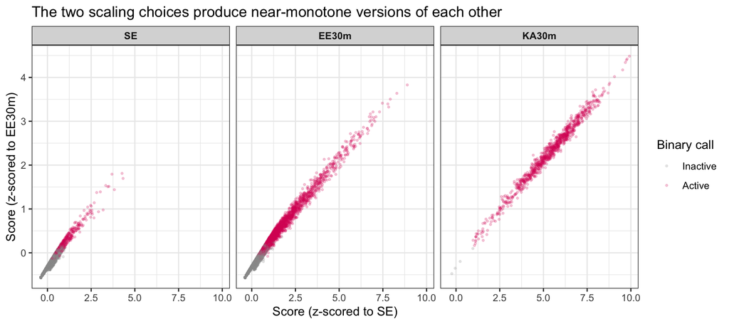

```r
ggplot(df) +
  aes(x = score_scaleSE, y = score_scaleEE, color = active_ref) +
  geom_point(alpha = 0.2, size = 0.6) +
  scale_color_manual(values = c("FALSE" = "gray60", "TRUE" = "#D81B60"),
                     labels = c("FALSE" = "Inactive", "TRUE" = "Active"), name = "Binary call") +
  facet_wrap(~activity_condition, nrow = 1) +
  labs(
    x = "Score (z-scored to SE)", y = "Score (z-scored to EE30m)",
    title = "The two scaling choices produce near-monotone versions of each other"
  ) +
  theme(strip.text = element_text(face = "bold"))
```

```r
df |>
  group_by(activity_condition) |>
  summarise(spearman_between_scalings = cor(score_scaleSE, score_scaleEE, method = "spearman"),
            .groups = "drop") |>
  gt() |>
  tab_header(title = "Rank correlation between the two scalings")
```

Rank correlation between the two scalings

| activity_condition | spearman_between_scalings |
| --- | --- |
| SE | 0.9960273 |
| EE30m | 0.9971665 |
| KA30m | 0.9879047 |

# What to conclude, and what to put in the figure

Assuming the chunks above behave as predicted:

For the figure itself, the most defensible presentation is to keep the PR panel but draw each condition’s prevalence baseline, and to report ROC-AUC alongside AUPRC in the caption. If a single headline number is wanted, use ROC-AUC.

```r
metrics |>
  left_join(matched_summary |> dplyr::select(activity_condition = condition, auprc_matched_mean),
            by = "activity_condition") |>
  gt() |>
  tab_header(title = "Summary: the same classifier, four ways of scoring it") |>
  cols_label(prevalence = "Prevalence", auprc = "AUPRC (reported)",
             roc = "ROC-AUC", auprc_normalised = "Normalised AUPRC",
             auprc_matched_mean = "AUPRC @ matched prevalence") |>
  fmt_number(columns = c(auprc, roc, auprc_normalised, auprc_matched_mean), decimals = 3) |>
  fmt_percent(columns = prevalence, decimals = 1)
```

Summary: the same classifier, four ways of scoring it

| activity_condition | Prevalence | AUPRC (reported) | ROC-AUC | Normalised AUPRC | AUPRC @ matched prevalence |
| --- | --- | --- | --- | --- | --- |
| SE | 6.2% | 0.873 | 0.988 | 0.865 | 0.873 |
| EE30m | 33.3% | 0.979 | 0.989 | 0.968 | 0.905 |
| KA30m | 99.6% | 1.000 | 1.000 | 1.000 | NaN |